# Machine Learning project. HAR

Luis Armando Salomon Hernandez

5/28/2021

## Introduction

We will work with the data from http://groupware.les.inf.puc-rio.br/har (see section on the Weight Lifting Exercise Dataset). The data itself has the information about personal activity from accelerometers on the belt, forearm, arm, and dumbell of 6 participants on the experiment.

Our purpose is to predict how they performed the exercise. We already have the data distributed in two sets: train and test. We will use the train data to find a suitable model and then predict on the test data.

The nature of the data suggests that we are in a classical classification problem. We will try to give a solution using Random Forest. This approach is quite natural in this type of problem.

```r
# Loading requiered packages and data
library(ggplot2)
library(dplyr)
library(randomForest)
library(e1071)
library(caret)
library(corrplot)
train_data <- read.csv(file = 'pml-training.csv')
test_data <- read.csv(file = 'pml-testing.csv')
```

## Data preparation

The train data has 19 622 observations and 160 variables and test data has 20 variables.

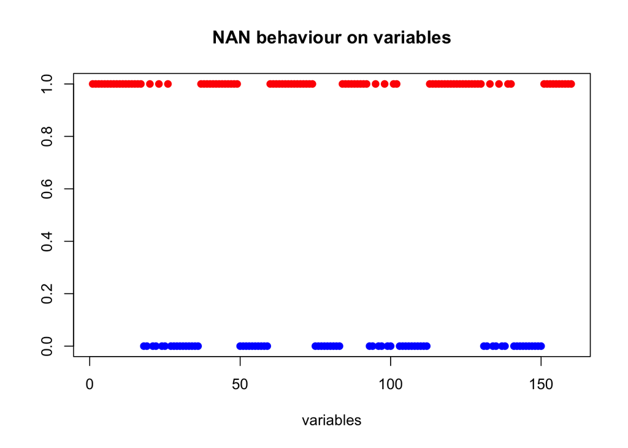

```r
# NAN analysis
index <-sapply(train_data, function(x) sum(is.na(x)))==0
plot(index, main = "NAN behaviour on variables",
     ylab="",
     xlab = "variables",
     col = ifelse(index < 1,'blue','red'), pch=19)
```

```r
train_data_clean <- train_data[,index] %>%
        select(classe,
               roll_forearm, pitch_forearm, yaw_forearm,total_accel_forearm,
               gyros_forearm_x, gyros_forearm_y, gyros_forearm_z,
               accel_forearm_x, accel_forearm_y, accel_forearm_z,
               magnet_forearm_x, magnet_forearm_y, magnet_forearm_z,
               roll_belt, pitch_belt, yaw_belt,total_accel_belt,
               gyros_belt_x, gyros_belt_y, gyros_belt_z,
               accel_belt_x, accel_belt_y, accel_belt_z,
               magnet_belt_x, magnet_belt_y, magnet_belt_z,
               roll_arm, pitch_arm, yaw_arm,total_accel_arm,
               gyros_arm_x, gyros_arm_y, gyros_arm_z,
               accel_arm_x, accel_arm_y, accel_arm_z,
               magnet_arm_x, magnet_arm_y, magnet_arm_z,
               roll_dumbbell, pitch_dumbbell, yaw_dumbbell,total_accel_dumbbell,
               gyros_dumbbell_x, gyros_dumbbell_y, gyros_dumbbell_z,
               accel_dumbbell_x, accel_dumbbell_y, accel_dumbbell_z,
               magnet_dumbbell_x, magnet_dumbbell_y, magnet_dumbbell_z
        )
test_data_clean <-test_data[ , -which(names(train_data_clean) %in% c("classe"))]
```

On the next figure we can see that, in general all variables are incorrelated, except for some small groups. However for this experiment we will continue without any further feature elimination

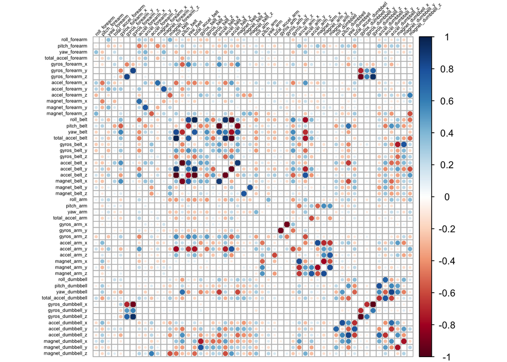

```r
train_data_numeric = train_data_clean %>% dplyr::select(where(is.numeric))
corrplot(cor(train_data_numeric), method = "circle", diag = FALSE,tl.col = "black",tl.srt = 45, tl.cex = 0.4)
```

## Model selection and results

As we mentioned at the beginning of the document, we are in a classification problem. We could use various approaches such as random tree, random forest, multinomial logistic regression, among others. We chose Random Forest for flexibility and strength. It is a powerful model that works quite well for these types of problems and is not very demanding in the assumptions for its use.

We use randon forest by two approaches. The first one with **randomForest** package and the second one with the **caret** package. This last one allow us to use crosvalidation automatically.

```r
# Random forest (no crossvalidation)
model_har <- randomForest(classe ~ ., data = train_data_clean, method = "rf", ntree = 50)
print(model_har)
```

```
##
## Call:
##  randomForest(formula = classe ~ ., data = train_data_clean, method = "rf",      ntree = 50)
##                Type of random forest: classification
##                      Number of trees: 50
## No. of variables tried at each split: 7
##
##         OOB estimate of  error rate: 0.37%
## Confusion matrix:
##      A    B    C    D    E  class.error
## A 5576    2    1    0    1 0.0007168459
## B   13 3778    6    0    0 0.0050039505
## C    1   11 3407    3    0 0.0043834015
## D    0    1   23 3189    3 0.0083955224
## E    0    1    1    6 3599 0.0022179096
```

```r
prediction_har <- predict(model_har, train_data_clean)
confusionMatrix(prediction_har, train_data_clean$classe)
```

```
## Confusion Matrix and Statistics
##
##           Reference
## Prediction    A    B    C    D    E
##          A 5580    0    0    0    0
##          B    0 3797    0    0    0
##          C    0    0 3422    0    0
##          D    0    0    0 3216    0
##          E    0    0    0    0 3607
##
## Overall Statistics
##
##                Accuracy : 1
##                  95% CI : (0.9998, 1)
##     No Information Rate : 0.2844
##     P-Value [Acc > NIR] : < 2.2e-16
##
##                   Kappa : 1
##
##  Mcnemar's Test P-Value : NA
##
## Statistics by Class:
##
##                      Class: A Class: B Class: C Class: D Class: E
## Sensitivity            1.0000   1.0000   1.0000   1.0000   1.0000
## Specificity            1.0000   1.0000   1.0000   1.0000   1.0000
## Pos Pred Value         1.0000   1.0000   1.0000   1.0000   1.0000
## Neg Pred Value         1.0000   1.0000   1.0000   1.0000   1.0000
## Prevalence             0.2844   0.1935   0.1744   0.1639   0.1838
## Detection Rate         0.2844   0.1935   0.1744   0.1639   0.1838
## Detection Prevalence   0.2844   0.1935   0.1744   0.1639   0.1838
## Balanced Accuracy      1.0000   1.0000   1.0000   1.0000   1.0000
```

As we can see the results are quite good.

```r
# Random forest with crossvalidation
control <- trainControl(method='repeatedcv',
                        number=10,
                        repeats=3,
                        search = 'random')
model_har_cv <- train(classe ~ ., data = train_data_clean, method = "rf", ntree = 5, trControl = control)
prediction_har_cv <- predict(model_har_cv, train_data_clean)
print(model_har_cv )
```

```
## Random Forest
##
## 19622 samples
##    52 predictor
##     5 classes: 'A', 'B', 'C', 'D', 'E'
##
## No pre-processing
## Resampling: Cross-Validated (10 fold, repeated 3 times)
## Summary of sample sizes: 17659, 17661, 17662, 17659, 17659, 17659, ...
## Resampling results across tuning parameters:
##
##   mtry  Accuracy   Kappa
##   14    0.9855942  0.9817760
##   21    0.9856794  0.9818856
##   40    0.9843543  0.9802079
##
## Accuracy was used to select the optimal model using the largest value.
## The final value used for the model was mtry = 21.
```

```r
confusionMatrix(prediction_har_cv, train_data_clean$classe)
```

```
## Confusion Matrix and Statistics
##
##           Reference
## Prediction    A    B    C    D    E
##          A 5578    2    0    1    1
##          B    1 3795    6    1    2
##          C    0    0 3412    3    0
##          D    0    0    4 3211    0
##          E    1    0    0    0 3604
##
## Overall Statistics
##
##                Accuracy : 0.9989
##                  95% CI : (0.9983, 0.9993)
##     No Information Rate : 0.2844
##     P-Value [Acc > NIR] : < 2.2e-16
##
##                   Kappa : 0.9986
##
##  Mcnemar's Test P-Value : NA
##
## Statistics by Class:
##
##                      Class: A Class: B Class: C Class: D Class: E
## Sensitivity            0.9996   0.9995   0.9971   0.9984   0.9992
## Specificity            0.9997   0.9994   0.9998   0.9998   0.9999
## Pos Pred Value         0.9993   0.9974   0.9991   0.9988   0.9997
## Neg Pred Value         0.9999   0.9999   0.9994   0.9997   0.9998
## Prevalence             0.2844   0.1935   0.1744   0.1639   0.1838
## Detection Rate         0.2843   0.1934   0.1739   0.1636   0.1837
## Detection Prevalence   0.2845   0.1939   0.1740   0.1638   0.1837
## Balanced Accuracy      0.9997   0.9994   0.9984   0.9991   0.9996
```

As expected we achieve a very good result also. The accuracy in both case is quite high. We could choose either of both models. For both we achieve similar results:

```r
prediction_har <- predict(model_har, test_data_clean)
prediction_har_cv <- predict(model_har_cv, test_data_clean)
HAR <- prediction_har
HAR_CV <- prediction_har_cv
data.frame(HAR, HAR_CV)
```

```
##    HAR HAR_CV
## 1    B      B
## 2    A      A
## 3    B      B
## 4    A      A
## 5    A      A
## 6    E      E
## 7    D      D
## 8    B      B
## 9    A      A
## 10   A      A
## 11   B      B
## 12   C      C
## 13   B      B
## 14   A      A
## 15   E      E
## 16   E      E
## 17   A      A
## 18   B      B
## 19   B      B
## 20   B      B
```

We should expect that out the sample error be small.